# Distributions of transformations

## This week in tgs data science

From a Grant Review studio for researchers as TSU and ABC on media literacy and tobacco-use prevention:

In the **implementation science** field, **efficacy** can be defined as the performance of an intervention under ideal and controlled circumstances, whereas **effectiveness** refers to its performance under ‘real-world’ conditions. [(link)](https://www.ncbi.nlm.nih.gov/pmc/articles/PMC3912314/)

How can this type of thinking shape our approach to data-science?

## Review

We use mathematical models to describe the distribution of outcomes.

\[ \text{birth weight} \sim N(\mu = 3100g, \sigma = 400) \]

## Review

From the mathematical model, we can calculate population quantities like mean and variance.

\[ E[\text{birth weight}] = 3100g \] \[ V[\text{birth weight}] = 400^2 \]

## Review

From the mathematical model, we can calculate population quantities like the range of the middle 95% of the distribution.

\[ \text{range middle 95%} = 3884 \text{ to } 2316\]

Or the interquartile range (IQR), which is the 25th to 75th quantiles:

\[ \text{IQR} = 3370 \text{ to } 2830\]

## Review

From the mathematical model, we can generate figures that describe the probability and density functions of the data.

```r
curve(
    dnorm(x, 3100, 400)
  , 1500
  , 4600
  , ylab = "Density"
  , xlab = "Birth weight (g)"
)
```

## Review

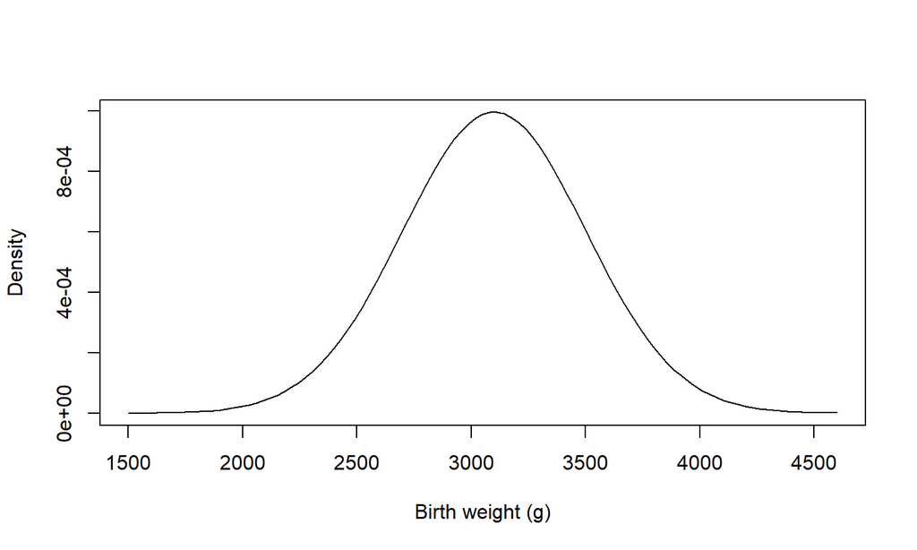

## Review

From the mathematical model, we can generate figures that describe the probability and density functions of the data.

```r
curve(
    pnorm(x, 3100, 400)
  , 1500
  , 4600
  , ylab = "Density"
  , xlab = "Birth weight (g)"
)
```

## Review

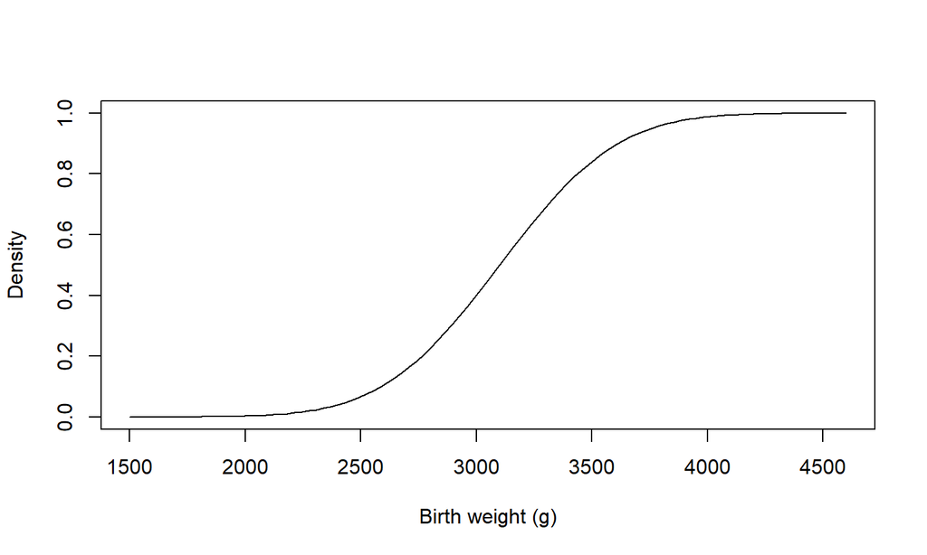

## Review

We can also determine the distribution of transformations of the data. (We are going to revisit this topic in greater detail.)

\[ \begin{align*} B & = \text{birth weight} \\ R &= \sqrt{\text{birth weight}} \end{align*} \]

## Review

We could also discover the distribution of the transformation by simulation.

```r
B <- rnorm(10000, 3100, 400)
R <- sqrt(B)
hist(R, freq = FALSE, main = "", breaks = 100)
curve(2*x*dnorm(x^2, 3100, 400), col = "blue", add = TRUE, lwd = 3)
```

## Review

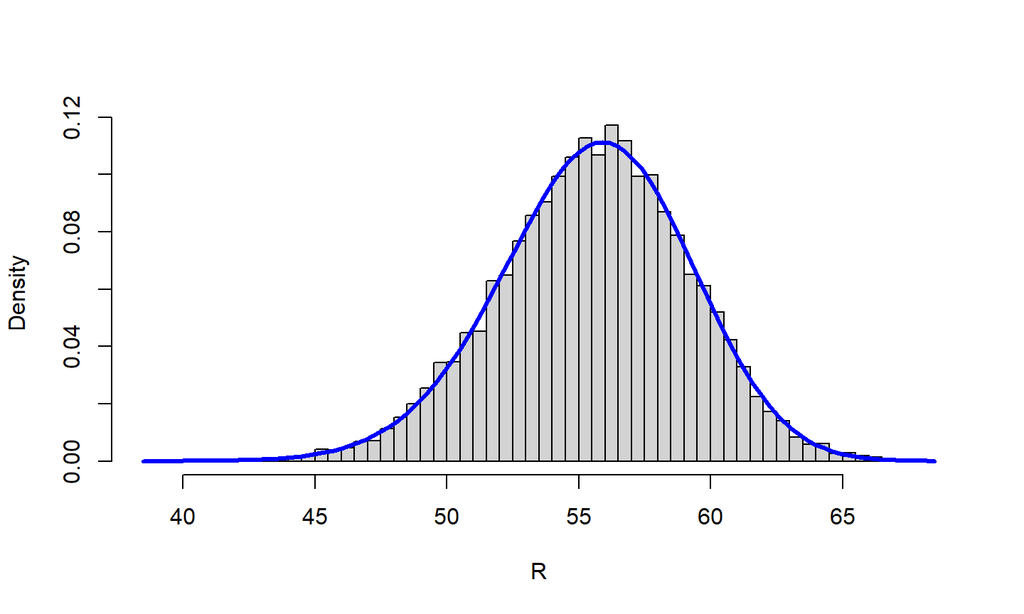

## NEW

We are also interested in transformations of samples of size \(N\).

\[\text{sample mean: }\ g(X_1, X_2, \ldots, X_N) = \frac{1}{N} \sum_{i=1}^N X_i \]

## NEW

We are also interested in transformations of samples of size \(N\).

\[\begin{align*}\text{sample variance: }&\\\ g(X_1, X_2, \ldots, X_N) &= \frac{1}{N} \sum_{i=1}^N (X_i - \bar{X})^2 \\ &=\left[\frac{1}{N}\sum_{i=1}^NX_i^2\right] - [\bar{X}]^2 \end{align*}\]

## NEW

We are also interested in transformations of samples of size \(N\).

\[\begin{align*}&\text{median: }\ g(X_1, X_2, \ldots, X_N) = \\ &\text{smallest }\ x\ \text{ such that}\ \frac{1}{N}\sum_{i = 1}^N I(X_i \leq x) = .5\end{align*}\]

## NEW

We are also interested in transformations of samples of size \(N\).

\[\begin{align*}&\text{min}(X_1, X_2, \ldots, X_N)\\ &\text{max}(X_1, X_2, \ldots, X_N)\end{align*}\]

## NEW

The distribution of outcomes derived from samples (min, max, median, mean, variance) is called the **sampling distribution**.

## The distribution of summary measures **AKA the sampling distribution**

[figure not shown]

## Example

Suppose we measure \(BMI\) in a sample of \(N=200\) individuals. For the sake of discussion, suppose \(BMI \sim N(\mu = 25,\ \sigma = 6.5)\).

## Example

Suppose we measure \(BMI\) in a sample of \(N=200\) individuals. For the sake of discussion, suppose \(BMI \sim N(\mu = 25,\ \sigma = 6.5)\).

The data from a single study might be simulated and summarized as follows:

```r
bmi <- rnorm(200, 25, 6.5)
mean(bmi)
```

```
## [1] 25.10887
```

## Example

What is the distribution of mean BMI?

Let simulate.

```r
mean_bmi <- rep(NA, 5000)
for(i in seq_along(mean_bmi)){
  bmi <- rnorm(200, 25, 6.5)
  mean_bmi[i] <- mean(bmi)
}
```

## Example

```r
hist(
    mean_bmi
  , breaks = 100
  , main = "Samping distribution of BMI"
  , freq = FALSE
)
```

## Example

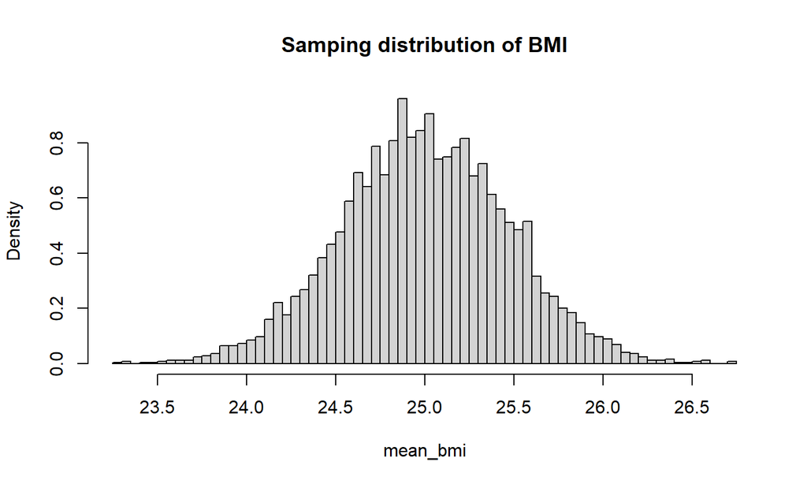

## Example

Just like the variance for **BMI** is related to the spread of **BMI** values when sampling individuals, the variance of the **sampling distribution** of summary statistics (mean, variance, median, min) is related to the spread of the summary measures when sampling studies of the same size.

## When we get to inference

The width of the **sampling distribution of the mean** is related to the precision with which the **mean BMI** is estimated.

One way to measure the width of the distribution is to calculate the **spread** of the middle 95% of the distribution.

## Example

```r
hist(
    mean_bmi
  , breaks = 100
  , main = "Samping distribution of BMI"
  , freq = FALSE
)
m95 <- quantile(mean_bmi, c(0.025, 0.975))
abline(v = m95, col = "blue", lty = 2)
```

## Example

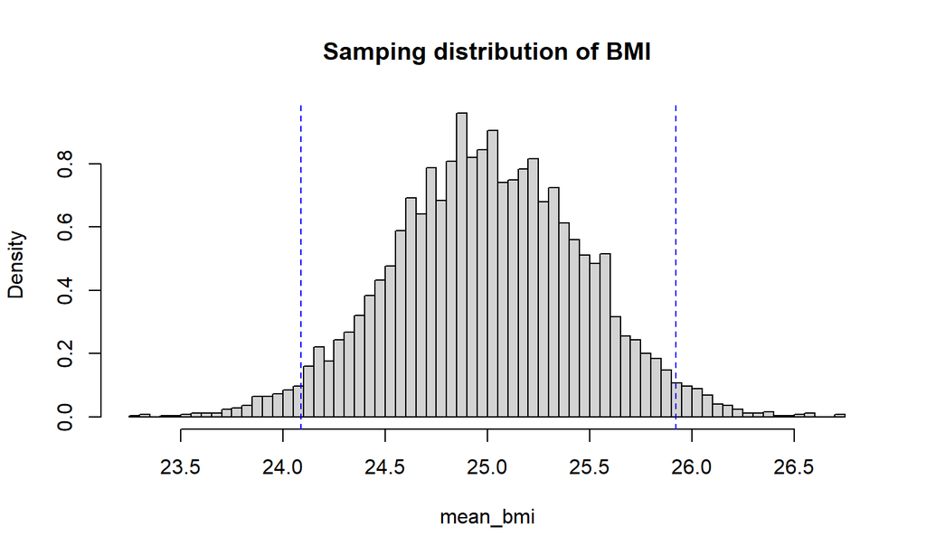

## Example

A tigher sampling distribution translates to more precise estimates of the mean.

## Example

```r
mean_bmi <- array(NA, dim = c(5000,2))
for(i in 1:nrow(mean_bmi)){
  mean_bmi[i, 1] <- rnorm(200, 25, 6.5) %>% mean
  mean_bmi[i, 2] <- rnorm(400, 25, 6.5) %>% mean
}

par(mfrow = c(2,1), mar = c(4,2,1,1))
for(j in 1:2){
  hist(
      mean_bmi[,j]
    , breaks = 100
    , main = c("N = 200","N = 400")[j]
    , xlab = ""
    , freq = FALSE
    , xlim = range(mean_bmi[,1])
  )
  m95 <- mean_bmi[,j] %>% quantile(c(0.025, 0.975))
  abline(v = m95, col = "blue", lty = 2)
}
```

## Example

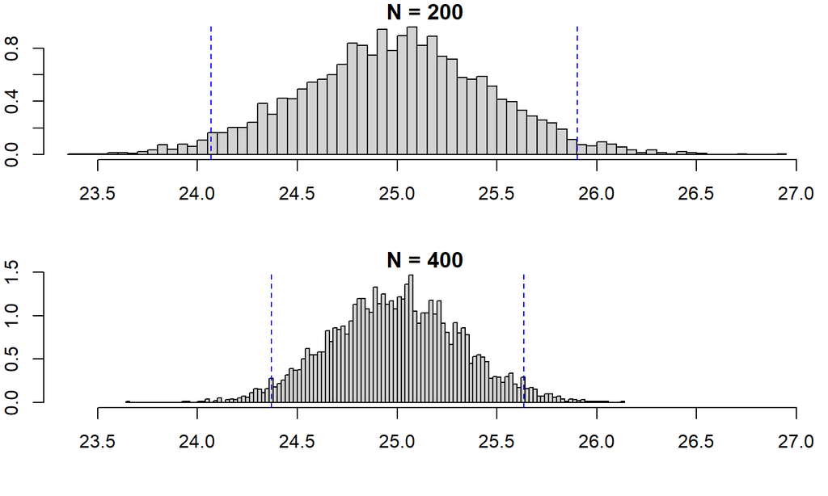

## How about the median?

```r
median_bmi <- array(NA, dim = c(5000,2))
for(i in 1:nrow(mean_bmi)){
  median_bmi[i, 1] <- rnorm(200, 25, 6.5) %>% median
  median_bmi[i, 2] <- rnorm(400, 25, 6.5) %>% median
}

par(mfrow = c(2,1), mar = c(4,2,1,1))
for(j in 1:2){
  hist(
      median_bmi[,j]
    , breaks = 100
    , main = c("N = 200","N = 400")[j]
    , xlab = ""
    , freq = FALSE
    , xlim = range(median_bmi)
  )
  m95 <- median_bmi[,j] %>% quantile(c(0.025, 0.975))
  abline(v = m95, col = "blue", lty = 2)
}
```

## How about the median?

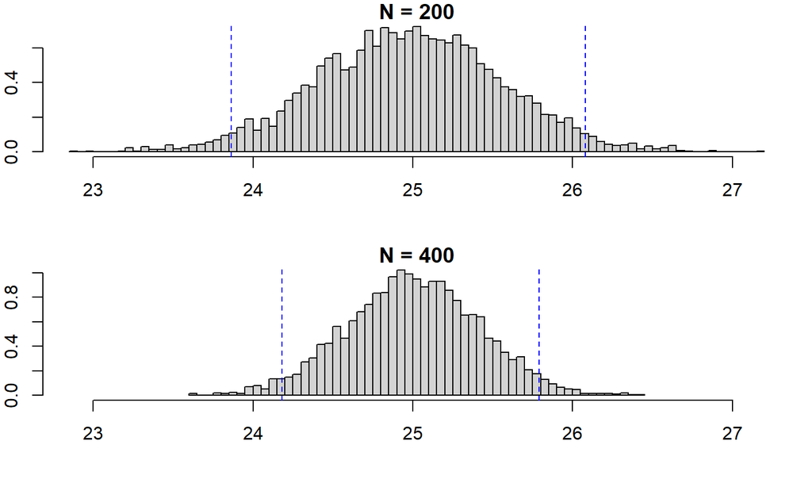

## How about the max?

```r
max_bmi <- array(NA, dim = c(5000,2))
for(i in 1:nrow(mean_bmi)){
  max_bmi[i, 1] <- rnorm(200, 25, 6.5) %>% max
  max_bmi[i, 2] <- rnorm(400, 25, 6.5) %>% max
}

par(mfrow = c(2,1), mar = c(4,2,1,1))
for(j in 1:2){
  hist(
      max_bmi[,j]
    , breaks = 100
    , main = c("N = 200","N = 400")[j]
    , xlab = ""
    , freq = FALSE
    , xlim = range(max_bmi)
  )
  m95 <- max_bmi[,j] %>% quantile(c(0.025, 0.975))
  abline(v = m95, col = "blue", lty = 2)
}
```

## How about the max?

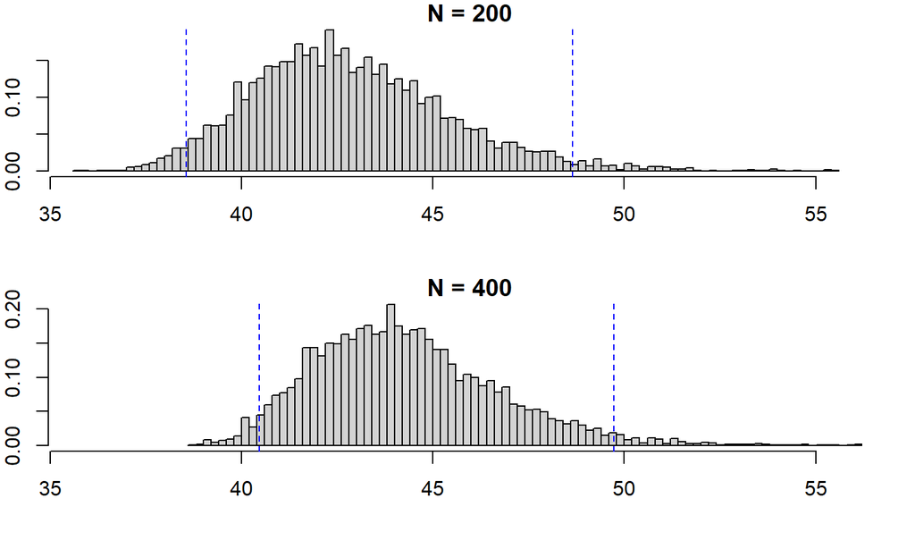

## Analytic tools for quantiles

You can simulate the sampling distribution of quantiles. Now, let’s discuss analytic tools for understanding sample quantiles.

## ECDF

The empirical cumulative density function

\[\text{Let } \boldsymbol{X}_N = X_1, X_2, \ldots, X_N\]

\[ \text{ecdf}(x, \boldsymbol{X}_N) = \frac{1}{N}\sum_{i=1}^NI(X_i \leq x) \]

## ECDF in R

```r
bmi <- rnorm(25, 25, 6.5) # New sample of size 25
bmi_ecdf <- ecdf(bmi)  # The output is a function
bmi_ecdf(30)
```

```
## [1] 0.84
```

## ECDF in R

```r
plot(bmi_ecdf, do.points = FALSE)
```

## ECDF in R

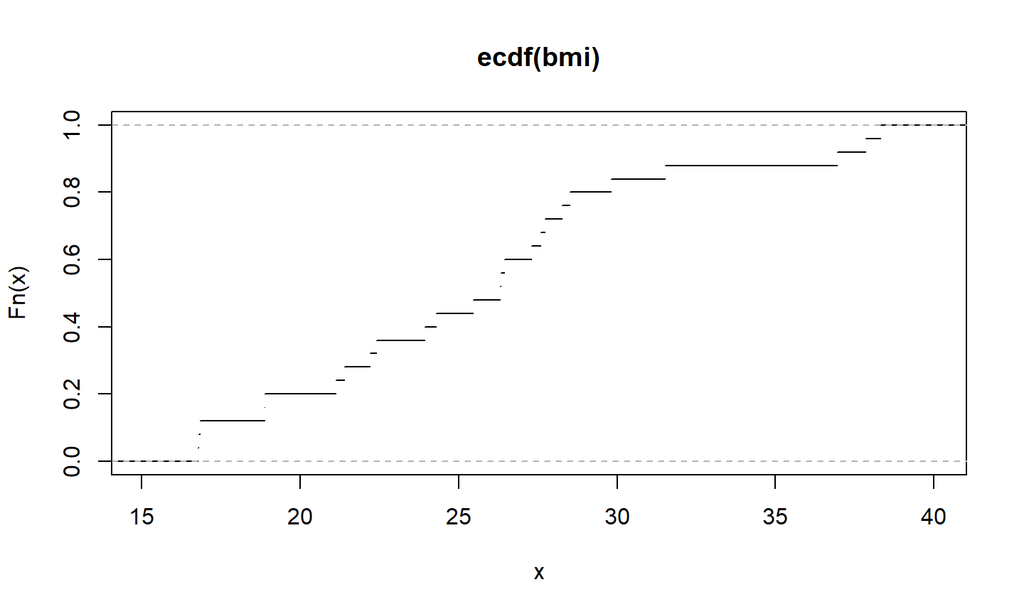

## ECDF in R

Note the connection with the CDF.

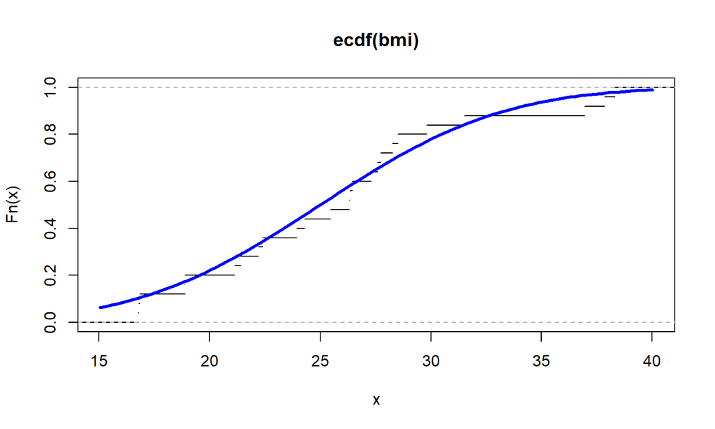

```r
plot(bmi_ecdf, do.points = FALSE)
curve(pnorm(x, 25, 6.5), add = TRUE, lwd = 3, col = "blue")
```

## ECDF in R

Let’s bump up the sample size.

```r
bmi <- rnorm(500, 25, 6.5) # New sample of size 25
bmi_ecdf <- ecdf(bmi)  # The output is a function
plot(bmi_ecdf, do.points = FALSE, col = "red", lwd = 3)
curve(pnorm(x, 25, 6.5), add = TRUE, lwd = 3, col = "blue")
legend(
    "topleft"
  , c("ECDF","CDF")
  , lwd = 3
  , col = c("red","blue")
  , bty = "n"
)
```

## ECDF in R

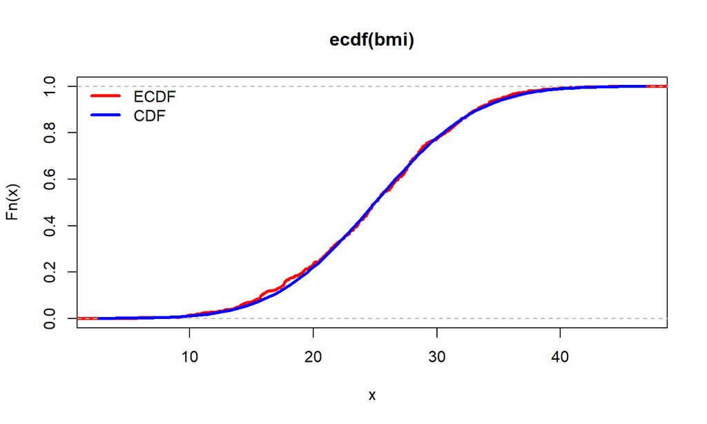

## Sample quantile function

The sample quantile function is approximately the inverse of the ECDF.

## Sample quantile function

```r
quantile(bmi, probs = c(.2, .7))
```

```
##      20%      70%
## 19.16391 28.27176
```

## Sample quantile function

```r
ps <- seq(0.01, 0.99, by = 0.01)
qs <- quantile(bmi, probs = ps)
plot(ps, qs, type = "p", pch = 16, col = "red")
curve(qnorm(x, 25, 6.5), add = TRUE, lwd = 3, col = "blue")
legend(
    "topleft"
  , c("quantile","qnorm")
  , lwd = 3
  , col = c("red","blue")
  , bty = "n"
)
```

## Sample quantile function

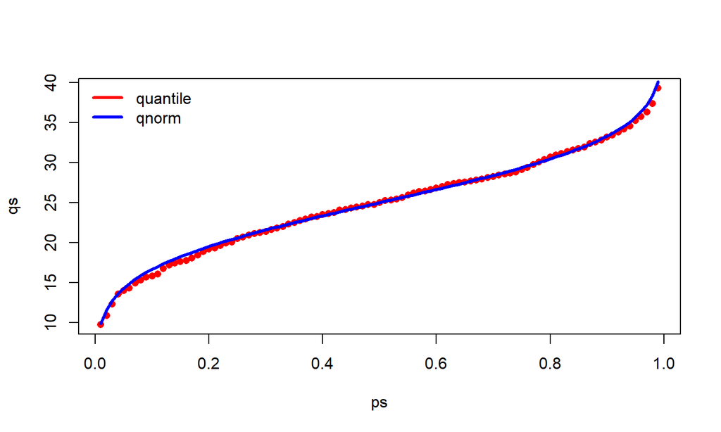

## Order statistics

\[\text{If } \boldsymbol{X}_N = X_1, X_2, \ldots, X_N\] \[\text{Let } \boldsymbol{X}_{(N)} = \text{sort}(\boldsymbol{X}_N)\]

\[\boldsymbol{X}_{(N)} = X_{(1)}, X_{(2)}, \ldots, X_{(N)}\]

## Order statistics

| Order statistic |  |  |
| --- | --- | --- |
| \(1^{st}\) | \(X_{(1)}\) | min |
| \(2^{nd}\) | \(X_{(2)}\) | \(2^{nd}\) smallest value |
|  | \(\ldots\) |  |
| \(N^{th}\) | \(X_{(N)}\) | max |

## Order statistics

What is the distribution of \(X_{(k)}\)?

## Order statistics

What is the distribution of \(X_{(k)}\)?

\[ f_{(k)}(x) = k\, {n \choose k}[F(x)]^{k-1}[1-F(x)]^{n-k}f(x)\]

## Order statistics

What is the distribution of \(X_{(k)}\)?

```r
fk <- function(x,k,n){
  k*
  choose(n,k)*
  (pnorm(x, 25, 6.5))^(k-1)*
  (1-pnorm(x, 25, 6.5))^(n-k)*
  dnorm(x, 25, 6.5)
}
```

## Order statistics

What is the distribution of \(X_{(3)}\)?

```r
curve(
    fk(x, 3, 25)
  , 3
  , 30
  , xlab = parse(text="X[(3)]")
  , ylab = "Density"
)
```

## Order statistics

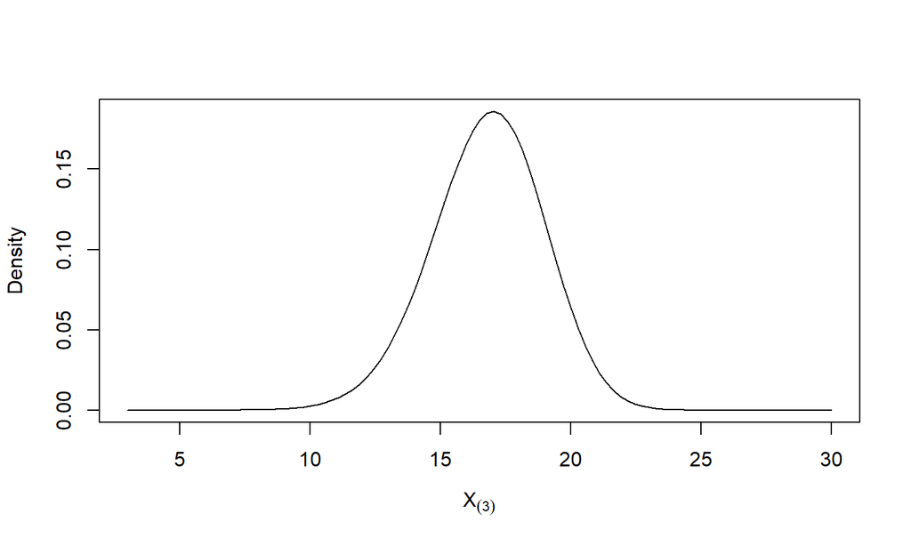

## Order statistics

What is the distribution of \(X_{(k)}\)?

\[ F_{(k)}(x) = \sum_{j = k}^N {n \choose j}[F(x)]^{j}[1-F(x)]^{n-j}\]

## Order statistics

What is the distribution of \(X_{(k)}\)?

```r
Fk <- function(x,k,n){
  pbinom(k-1, n, pnorm(x, 25, 6.5), lower.tail = FALSE)
}
```

## Order statistics

What is the distribution of \(X_{(3)}\)?

```r
curve(
    Fk(x, 3, 25)
  , 3
  , 30
  , xlab = parse(text="X[(3)]")
  , ylab = "Probability"
)
```

## Order statistics

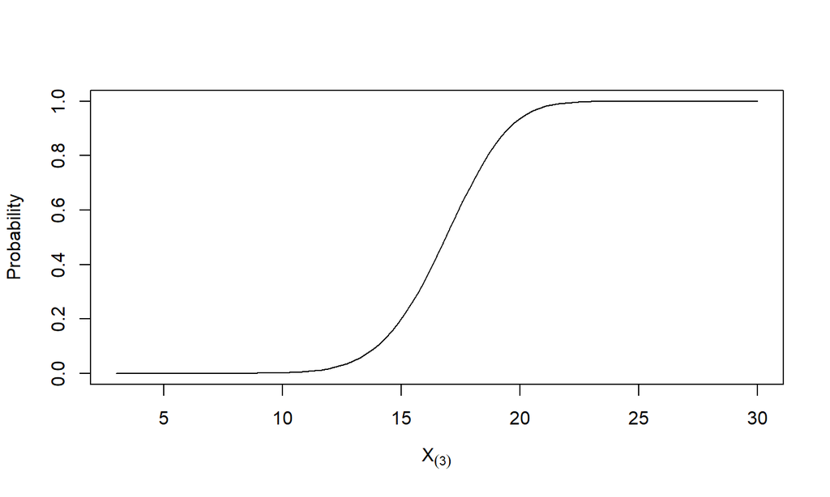

## Does this match with a simulated sampling distribution?

```r
M <- 5000 # studies
N <- 25 # sample size
bmis <- array(rnorm(M*N, 25, 6.5), c(M, N))
thirds <- bmis %>% apply(1, function(x){sort(x)[3]})
hist(thirds, breaks = 100, freq = FALSE, main = "")
curve(fk(x, 3, 25), lwd = 3, add = TRUE, col = "blue")
```

## Does this match with a simulated sampling distribution?

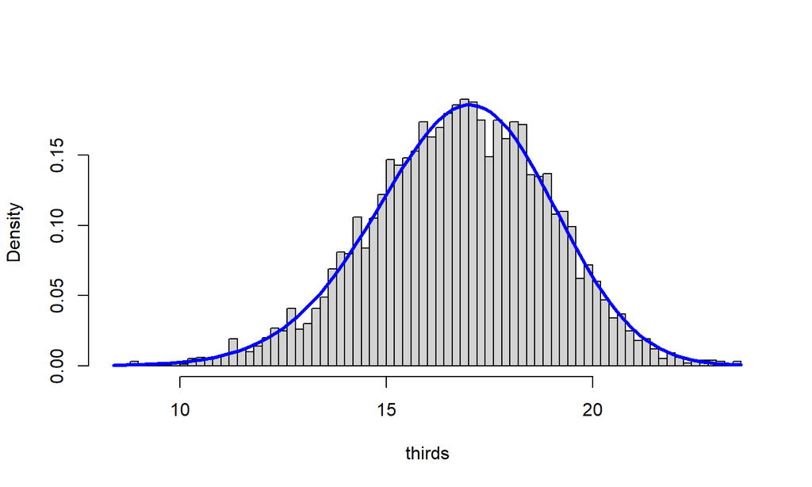

## Does this match with a simulated sampling distribution?

```r
plot(ecdf(thirds), xlab = parse(text = "CDF~BMI[(3)]"), main = "")
curve(Fk(x, 3, 25), lwd = 3, add = TRUE, col = "blue")
legend("topleft",c("SIM","Theoretical"), col = c(1,4), lwd = 3, bty = "n")
```

## Does this match with a simulated sampling distribution?

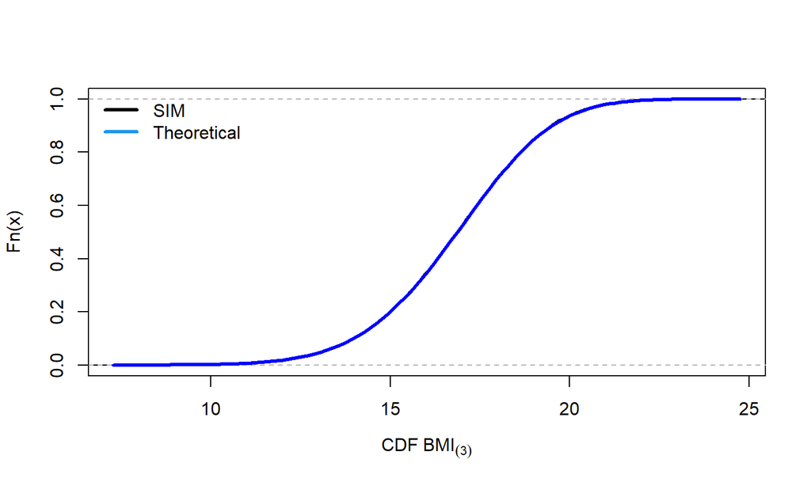

## What is the connection between order statistics and quantiles?

What is the median of a sample of 25?